# Ch03 単語の出現頻度と特定の文書での出現頻度の分析

単語の出現頻度というのは 文書を数量化する１つの手法である. 一方, あまり出現しない単語に重みを強くする 方法がある. これを逆頻度解析という. 頻度解析と逆頻度解析を組み合わせると, 普段はわからないことが色々と見えてくる.

ある単語の逆文書頻度は次ぎのように定義されている.

$$idf(\textrm{単語}) = \log(\frac{n_{文書}}{n_{単語を含む文書}})$$

# ライブラリー

```r
# load libs
libs <- c( "tidyverse", "tidytext",
           "janeaustenr", "gutenbergr", "scales",
           "wordcloud")
for( lib in libs ) {
    if(!require(lib, character.only = TRUE)) {
        install.packages(lib)
        library(lib, character.only = TRUE)
    }
}
```

# 単語出現頻度

まずは単語出現頻度(tf)を調べてから tf-idfを調べる.

```r
book_words <-
  austen_books() %>%
  unnest_tokens(word, text) %>%
  count(book, word, sort = TRUE) %>%
  ungroup()

total_words <-
  book_words %>%
  group_by(book) %>%
  summarise(total = sum (n))

book_words <- left_join(book_words, total_words, by = "book")

book_words
```

| book | word | n | total |
| --- | --- | --- | --- |
| Mansfield Park | the | 6206 | 160460 |
| Mansfield Park | to | 5475 | 160460 |
| Mansfield Park | and | 5438 | 160460 |
| Emma | to | 5239 | 160996 |
| Emma | the | 5201 | 160996 |
| Emma | and | 4896 | 160996 |
| Mansfield Park | of | 4778 | 160460 |
| Pride & Prejudice | the | 4331 | 122204 |
| Emma | of | 4291 | 160996 |
| Pride & Prejudice | to | 4162 | 122204 |

[output cut: 9990 more lines]

上記の整理データを使い, 単語出現頻度を調べる. グラフを見るとどの小説でも, 単語の利用頻度の分布は べき乗則に従っているように見える. つまり, 利用頻度が高い単語の数ほど少なく, 利用頻度が低い単語の数ほど多い.

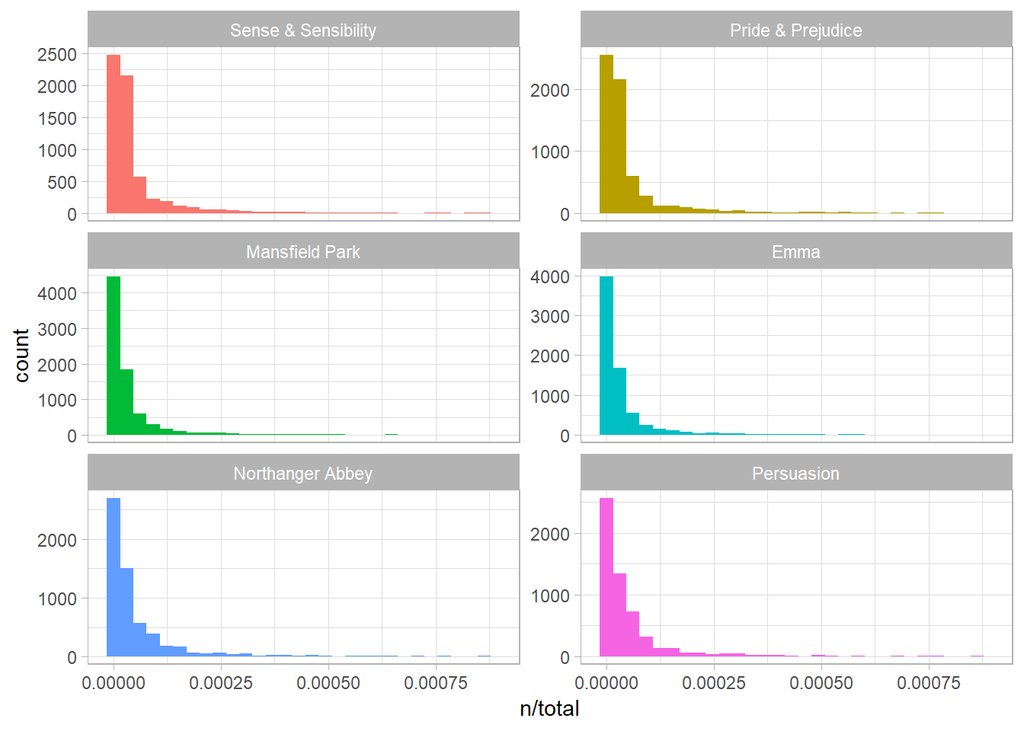

```r
ggplot(book_words, aes(n / total, fill = book)) +
  geom_histogram(show.legend = FALSE) +
  xlim(NA, 0.0009) +
  facet_wrap( ~ book, ncol = 2, scales = "free_y") +
  theme_light()
```

# ジップの法則

べき乗則に従うことをジップの法則という. もっと正確にいうとジップの法則では、 単語の出現頻度は出現頻度順位に頒布例すると主張している.

```r
freq_by_rank <-
  book_words %>%
  group_by(book) %>%
  mutate(
    rank = row_number(),
    `term frequency` = n / total
  )
freq_by_rank %>% head(15)
```

| book | word | n | total | rank | term frequency |
| --- | --- | --- | --- | --- | --- |
| Mansfield Park | the | 6206 | 160460 | 1 | 0.03867631 |
| Mansfield Park | to | 5475 | 160460 | 2 | 0.03412065 |
| Mansfield Park | and | 5438 | 160460 | 3 | 0.03389007 |
| Emma | to | 5239 | 160996 | 1 | 0.03254118 |
| Emma | the | 5201 | 160996 | 2 | 0.03230515 |
| Emma | and | 4896 | 160996 | 3 | 0.03041069 |
| Mansfield Park | of | 4778 | 160460 | 4 | 0.02977689 |
| Pride & Prejudice | the | 4331 | 122204 | 1 | 0.03544074 |
| Emma | of | 4291 | 160996 | 4 | 0.02665284 |
| Pride & Prejudice | to | 4162 | 122204 | 2 | 0.03405780 |

[output cut: 5 more lines]

ランクと出現頻度の関係をプロットする.

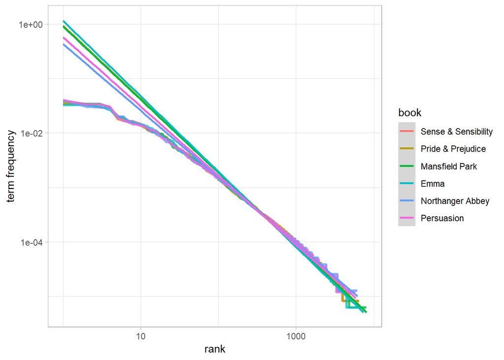

```r
freq_by_rank %>%
  ggplot(aes(rank, `term frequency`, color = book)) +
  geom_line(size = 1.1, alpha = .8, show.legend = FALSE) +
  scale_x_log10() +
  scale_y_log10() +
  theme_light() +
  geom_smooth(method = "lm")
```

```r
rank_subset <-
  freq_by_rank %>%
  filter(
    rank < 500,
    rank > 10
  )

lm(log10(`term frequency`) ~ log10(rank), data = rank_subset)
```

```
##
## Call:
## lm(formula = log10(`term frequency`) ~ log10(rank), data = rank_subset)
##
## Coefficients:
## (Intercept)  log10(rank)
##     -0.6226      -1.1125
```

# bind_tf_idf

`tf-idf`の考え方は, 文書のコレクション, コーパスでの頻出後の重みを減らし, 希少語の重みを増やして, ここの文書における重要語を 探し出すというものである. つまり, 一般にはあまり出現しないものの, テキストの中では重要な単語を探し出そうというものです.

```r
book_words <-
  book_words %>%
  bind_tf_idf(word, book, n)
book_words %>% head()
```

| book | word | n | total | tf | idf | tf_idf |
| --- | --- | --- | --- | --- | --- | --- |
| Mansfield Park | the | 6206 | 160460 | 0.03867631 | 0 | 0 |
| Mansfield Park | to | 5475 | 160460 | 0.03412065 | 0 | 0 |
| Mansfield Park | and | 5438 | 160460 | 0.03389007 | 0 | 0 |
| Emma | to | 5239 | 160996 | 0.03254118 | 0 | 0 |
| Emma | the | 5201 | 160996 | 0.03230515 | 0 | 0 |
| Emma | and | 4896 | 160996 | 0.03041069 | 0 | 0 |

出現頻度が高い単語ではidfが0になるので, tf-idfも0になる.

```r
# tf-idfが高い単語を抽出
book_words %>%
  select(-total) %>%
  arrange(desc(tf_idf))
```

| book | word | n | tf | idf | tf_idf |
| --- | --- | --- | --- | --- | --- |
| Sense & Sensibility | elinor | 623 | 5.193528e-03 | 1.7917595 | 9.305552e-03 |
| Sense & Sensibility | marianne | 492 | 4.101470e-03 | 1.7917595 | 7.348847e-03 |
| Mansfield Park | crawford | 493 | 3.072417e-03 | 1.7917595 | 5.505032e-03 |
| Pride & Prejudice | darcy | 373 | 3.052273e-03 | 1.7917595 | 5.468939e-03 |
| Persuasion | elliot | 254 | 3.036171e-03 | 1.7917595 | 5.440088e-03 |
| Emma | emma | 786 | 4.882109e-03 | 1.0986123 | 5.363545e-03 |
| Northanger Abbey | tilney | 196 | 2.519928e-03 | 1.7917595 | 4.515105e-03 |
| Emma | weston | 389 | 2.416209e-03 | 1.7917595 | 4.329266e-03 |
| Pride & Prejudice | bennet | 294 | 2.405813e-03 | 1.7917595 | 4.310639e-03 |
| Persuasion | wentworth | 191 | 2.283105e-03 | 1.7917595 | 4.090775e-03 |

[output cut: 9990 more lines]

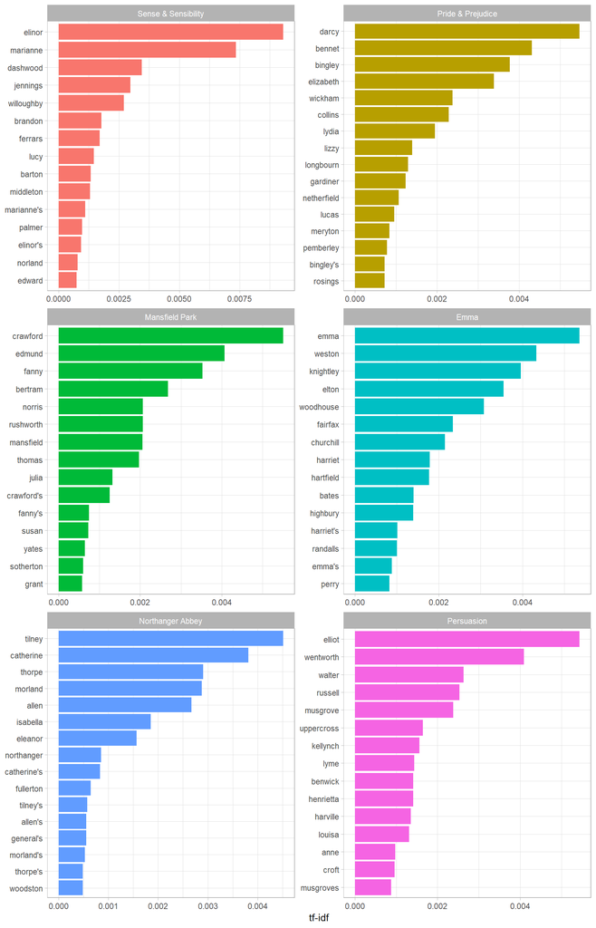

```r
# tf-idfが高い単語を可視化
book_words %>%
  arrange(desc(tf_idf)) %>%
  mutate(word = as_factor(word) %>% fct_rev()) %>%
  group_by(book) %>%
  top_n(15) %>%
  ungroup()  %>%
  ggplot(aes(word, tf_idf, fill = book)) +
  geom_col(show.legend = FALSE) +
  labs(x = NULL, y = "tf-idf") +
  facet_wrap( ~ book, ncol = 2, scales = "free") +
  coord_flip() +
  theme_light()
```

# 物理学書のコーパス

```r
book_ids <- c (37729, 14725, 13476, 5001)
physics <-
  gutenberg_download(book_ids, meta_fields = "author")
```

```
## Determining mirror for Project Gutenberg from http://www.gutenberg.org/robot/harvest
```

```
## Using mirror http://aleph.gutenberg.org
```

```r
physics_words <-
  physics %>%
  unnest_tokens(word, text) %>%
  count(author, word, sort = TRUE) %>%
  ungroup()

physics_words %>% head(10)
```

| author | word | n |
| --- | --- | --- |
| Galilei, Galileo | the | 3760 |
| Tesla, Nikola | the | 3604 |
| Huygens, Christiaan | the | 3553 |
| Einstein, Albert | the | 2994 |
| Galilei, Galileo | of | 2049 |
| Einstein, Albert | of | 2030 |
| Tesla, Nikola | of | 1737 |
| Huygens, Christiaan | of | 1708 |
| Huygens, Christiaan | to | 1207 |
| Tesla, Nikola | a | 1176 |

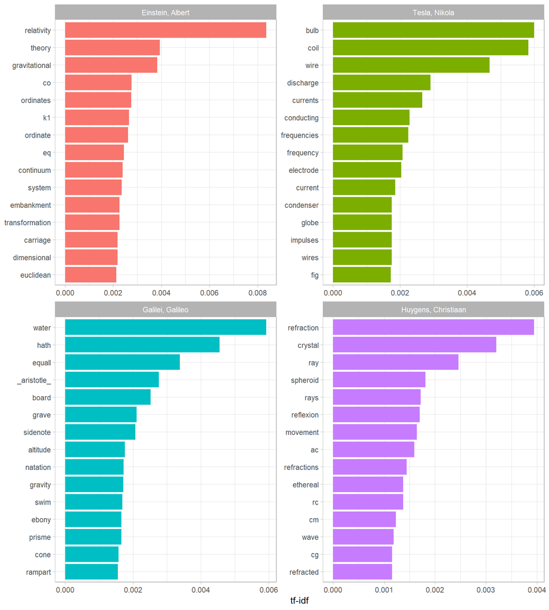

```r
# tf-idfを計算
plot_physics <-
  physics_words %>%
  bind_tf_idf(word, author, n) %>%
  arrange(desc(tf_idf)) %>%
  mutate(word = as_factor(word) %>% fct_rev()) %>%
  mutate(author = as_factor(author))

plot_physics %>%
  group_by(author) %>%
  top_n(15, tf_idf) %>%
  ungroup() %>%
  mutate(word = reorder(word, tf_idf)) %>%
  ggplot(aes(word, tf_idf, fill = author)) +
  geom_col(show.legend = FALSE) +
  labs(x = NULL, y = "tf-idf") +
  facet_wrap(~author, ncol = 2, scales = "free") +
  coord_flip()+
  theme_light()
```

アインシュタインの`eq`とは何であるのかを調べる.

```r
physics %>%
  filter(str_detect(text, "eq\\.")) %>%
  select(text)
```

| text |
| --- |
| eq. 1: file eq01.gif |
| eq. 2: file eq02.gif |
| eq. 3: file eq03.gif |
| eq. 4: file eq04.gif |
| eq. 05a: file eq05a.gif |
| eq. 05b: file eq05b.gif |
| the distance between the points being eq. 06 . |
| direction of its length with a velocity v is eq. 06 of a metre. |
| velocity v=c we should have eq. 06a , |
| the rod as judged from K1 would have been eq. 06 ; |

[output cut: 45 more lines]

意味のない単語を取り除き, データをクリーニングする.

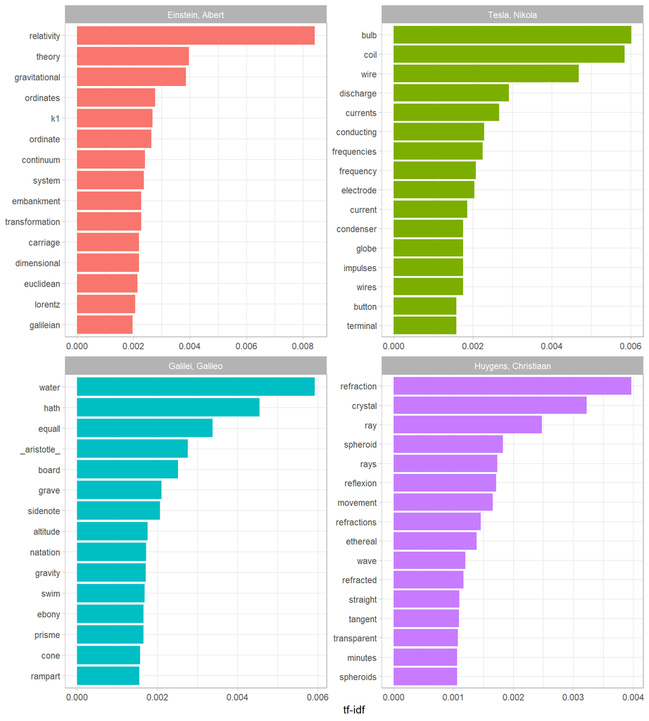

```r
mystopwords <-
  data_frame(
    word = c("eq", "co", "rc", "ac", "ak", "bn",
             "fig", "file", "cg", "cb", "cm")
  )

physics_words <-
  anti_join(physics_words, mystopwords, by = "word")

plot_physics <-
  physics_words %>%
  bind_tf_idf(word, author, n) %>%
  arrange(desc(tf_idf)) %>%
  mutate(word = as_factor(word) %>% fct_rev()) %>%
  group_by(author) %>%
  top_n(15, tf_idf) %>%
  ungroup() %>%
  mutate(
    author = as_factor(author)
  )


ggplot(plot_physics, aes(word, tf_idf, fill = author)) +
  geom_col(show.legend = FALSE) +
  labs(x = NULL, y = "tf-idf") +
  facet_wrap(~author, ncol = 2, scales = "free") +
  coord_flip() +
  theme_light()
```

# まとめ

`tf-idf`分析を使うことで, 文書コレクションの中にある1つの文書で 特徴的な単語を探しだすことができる. つまり, 単語出現頻度という単純な指標を掘り下げるだけでも, 多くのことがわかる. そして, dplyrを使えば容易に分析が実現できることがわかる.